# hw02

Nima

9/22/2019

### **Answer to exercise 1.1:**

```r
knitr::kable(A1.1 <- gapminder %>%
    filter(country %in% c("Iran","Turkey","Saudi Arabia"),year>=1970&year<1980))
```

| country | continent | year | lifeExp | pop | gdpPercap |
| --- | --- | --- | --- | --- | --- |
| Iran | Asia | 1972 | 55.234 | 30614000 | 9613.819 |
| Iran | Asia | 1977 | 57.702 | 35480679 | 11888.595 |
| Saudi Arabia | Asia | 1972 | 53.886 | 6472756 | 24837.429 |
| Saudi Arabia | Asia | 1977 | 58.690 | 8128505 | 34167.763 |
| Turkey | Europe | 1972 | 57.005 | 37492953 | 3450.696 |
| Turkey | Europe | 1977 | 59.507 | 42404033 | 4269.122 |

### **Answer to exercise 1.2:**

```r
knitr::kable(A1.1 %>%
    select(country,gdpPercap))
```

| country | gdpPercap |
| --- | --- |
| Iran | 9613.819 |
| Iran | 11888.595 |
| Saudi Arabia | 24837.429 |
| Saudi Arabia | 34167.763 |
| Turkey | 3450.696 |
| Turkey | 4269.122 |

### **Answer to exercise 1.3:**

```r
datatable(gapminder %>%
    mutate(PreviouslifeExp=lag(lifeExp)) %>%
    filter(lifeExp-PreviouslifeExp<0) %>%
    select(-PreviouslifeExp))
```

|  | country | continent | year | lifeExp | pop | gdpPercap |
| --- | --- | --- | --- | --- | --- | --- |
| 1 | Albania | Europe | 1992 | 71.581 | 3326498 | 2497.437901 |
| 2 | Algeria | Africa | 1952 | 43.077 | 9279525 | 2449.008185 |
| 3 | Angola | Africa | 1952 | 30.015 | 4232095 | 3520.610273 |
| 4 | Angola | Africa | 1987 | 39.906 | 7874230 | 2430.208311 |
| 5 | Australia | Oceania | 1952 | 69.12 | 8691212 | 10039.59564 |
| 6 | Austria | Europe | 1952 | 66.8 | 6927772 | 6137.076492 |
| 7 | Bahrain | Asia | 1952 | 50.939 | 120447 | 9867.084765 |
| 8 | Bangladesh | Asia | 1952 | 37.484 | 46886859 | 684.2441716 |
| 9 | Benin | Africa | 1952 | 38.223 | 1738315 | 1062.7522 |
| 10 | Benin | Africa | 2002 | 54.406 | 7026113 | 1372.877931 |

[output cut: 211 more lines]

### **Answer to exercise 1.4 part 1:**

```r
datatable(gapminder %>%
    group_by(country) %>%
    filter(gdpPercap==max(gdpPercap)))
```

|  | country | continent | year | lifeExp | pop | gdpPercap |
| --- | --- | --- | --- | --- | --- | --- |
| 1 | Afghanistan | Asia | 1982 | 39.854 | 12881816 | 978.0114388 |
| 2 | Albania | Europe | 2007 | 76.423 | 3600523 | 5937.029526 |
| 3 | Algeria | Africa | 2007 | 72.301 | 33333216 | 6223.367465 |
| 4 | Angola | Africa | 1967 | 35.985 | 5247469 | 5522.776375 |
| 5 | Argentina | Americas | 2007 | 75.32 | 40301927 | 12779.37964 |
| 6 | Australia | Oceania | 2007 | 81.235 | 20434176 | 34435.36744 |
| 7 | Austria | Europe | 2007 | 79.829 | 8199783 | 36126.4927 |
| 8 | Bahrain | Asia | 2007 | 75.635 | 708573 | 29796.04834 |
| 9 | Bangladesh | Asia | 2007 | 64.062 | 150448339 | 1391.253792 |
| 10 | Belgium | Europe | 2007 | 79.441 | 10392226 | 33692.60508 |

[output cut: 132 more lines]

### **Answer to exercise 1.4 part 2:**

```r
knitr::kable(gapminder %>%
    mutate(row_number=row_number()) %>%
    arrange(desc(gdpPercap)) %>%
    filter(row_number %in% sort(gapminder$gdpPercap,decreasing = TRUE,index.return=TRUE)$ix[1:3]|row_number %in% sort(gapminder$gdpPercap,index.return=TRUE)$ix[1:3]) %>%
    select(-row_number))
```

| country | continent | year | lifeExp | pop | gdpPercap |
| --- | --- | --- | --- | --- | --- |
| Kuwait | Asia | 1957 | 58.033 | 212846 | 113523.1329 |
| Kuwait | Asia | 1972 | 67.712 | 841934 | 109347.8670 |
| Kuwait | Asia | 1952 | 55.565 | 160000 | 108382.3529 |
| Lesotho | Africa | 1952 | 42.138 | 748747 | 298.8462 |
| Congo, Dem. Rep. | Africa | 2007 | 46.462 | 64606759 | 277.5519 |
| Congo, Dem. Rep. | Africa | 2002 | 44.966 | 55379852 | 241.1659 |

### **Answer to exercise 1.5:**

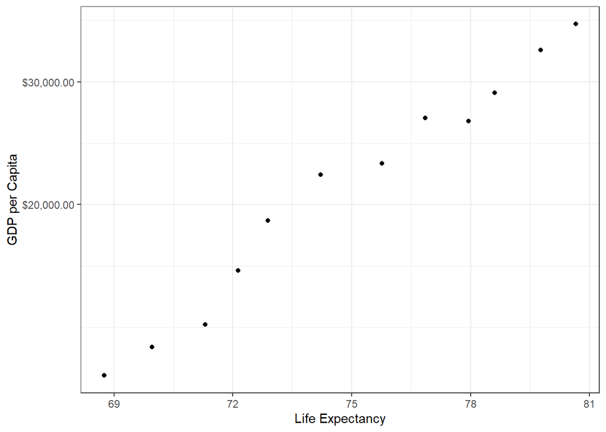

```r
gapminder %>%
  filter(country=="Canada") %>%
  ggplot()+
  geom_point(aes(x=lifeExp, y=gdpPercap))+
  theme_bw()+
  scale_y_log10("GDP per Capita",labels=scales::dollar_format())+
  xlab("Life Expectancy")
```

### **Answer to exercise 2:**

From the gapminder dataset I chose the *continent* and *population* variables for the latest year available in the data (2007).

Here is a summary of the variables:

The frequency of the continents are as follows:  
-Africa :52  
-Americas:25  
-Asia :33  
-Europe :30  
-Oceania : 2  
The mode of the continent variable is Africa .

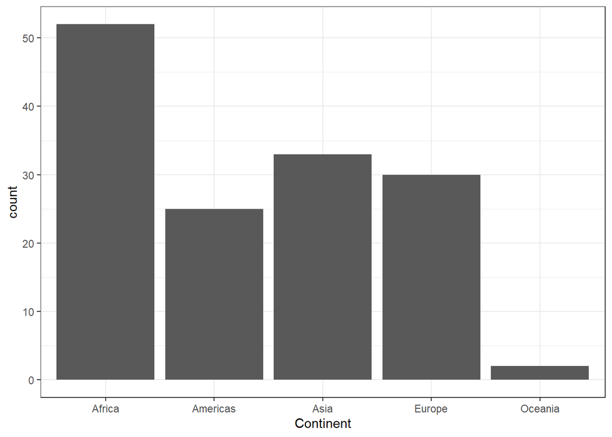

Min, max, median, 1st and 3rd quantile of the population variable are as follows:  
-Min. :1.996e+05  
-1st Qu.:4.508e+06  
-Median :1.052e+07  
-Mean :4.402e+07  
-3rd Qu.:3.121e+07  
-Max. :1.319e+09

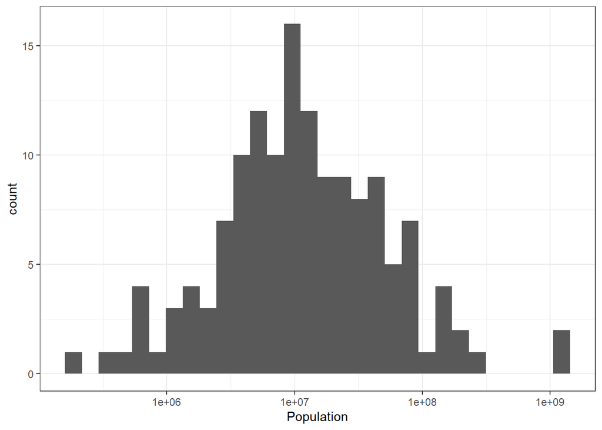

### **Answer to exercise 3:**

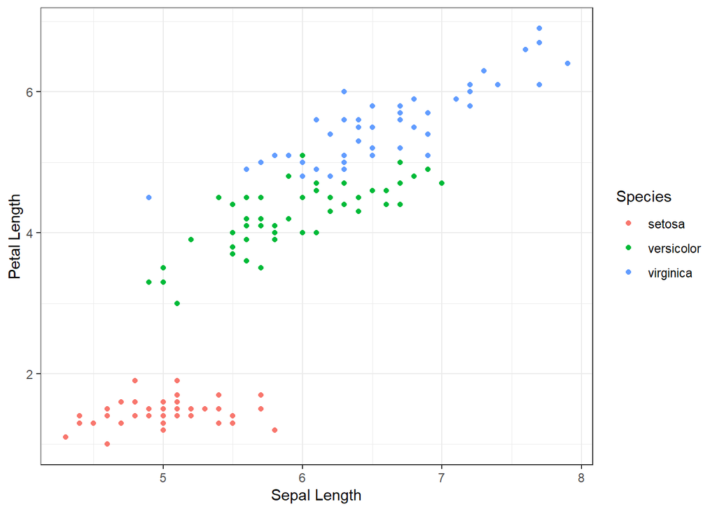

```r
ggplot(iris)+
  geom_point(aes(x=Sepal.Length , y=Petal.Length, color=Species))+
  theme_bw()+
  xlab("Sepal Length")+
  ylab("Petal Length")
```

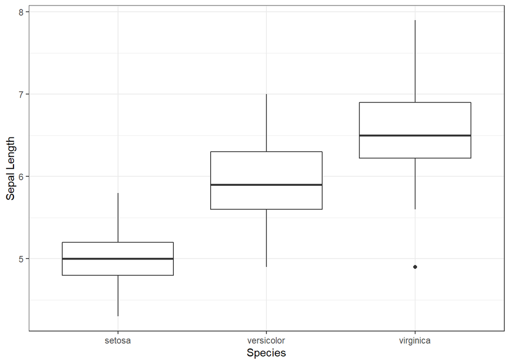

```r
ggplot(iris)+
  geom_boxplot(aes(Species, Sepal.Length))+
  theme_bw()+
  ylab("Sepal Length")
```

### **Answer to exercise 3, Recycling:**

The result of the code below is:

```r
filter(gapminder %>% ungroup(), country == c("Rwanda", "Afghanistan"))
```

|  | country | continent | year | lifeExp | pop | gdpPercap |
| --- | --- | --- | --- | --- | --- | --- |
| 1 | Afghanistan | Asia | 1957 | 30.332 | 9240934 | 820.8530296 |
| 2 | Afghanistan | Asia | 1967 | 34.02 | 11537966 | 836.1971382 |
| 3 | Afghanistan | Asia | 1977 | 38.438 | 14880372 | 786.11336 |
| 4 | Afghanistan | Asia | 1987 | 40.822 | 13867957 | 852.3959448 |
| 5 | Afghanistan | Asia | 1997 | 41.763 | 22227415 | 635.341351 |
| 6 | Afghanistan | Asia | 2007 | 43.828 | 31889923 | 974.5803384 |
| 7 | Rwanda | Africa | 1952 | 40 | 2534927 | 493.3238752 |
| 8 | Rwanda | Africa | 1962 | 43 | 3051242 | 597.4730727 |
| 9 | Rwanda | Africa | 1972 | 44.6 | 3992121 | 590.5806638 |
| 10 | Rwanda | Africa | 1982 | 46.218 | 5507565 | 881.5706467 |

[output cut: 2 more lines]

This is not the intended result. The code above searches through the rows for “Rwanda” and “Afghanistan” in a cycle. for example for the row belonging to Afghanistan in 1952, it has searched for “Rwanda” and gave a FALSE answer and passed to the next row. For the next row which is Afaghanistan in 1957, it has searched for “Afghanistan”. Therefore the answer was TRUE and you can see this row in the result. The correct code to filter the data for these two countries is:

```r
filter(gapminder, country %in% c("Rwanda", "Afghanistan"))
```

|  | country | continent | year | lifeExp | pop | gdpPercap |
| --- | --- | --- | --- | --- | --- | --- |
| 1 | Afghanistan | Asia | 1952 | 28.801 | 8425333 | 779.4453145 |
| 2 | Afghanistan | Asia | 1957 | 30.332 | 9240934 | 820.8530296 |
| 3 | Afghanistan | Asia | 1962 | 31.997 | 10267083 | 853.10071 |
| 4 | Afghanistan | Asia | 1967 | 34.02 | 11537966 | 836.1971382 |
| 5 | Afghanistan | Asia | 1972 | 36.088 | 13079460 | 739.9811058 |
| 6 | Afghanistan | Asia | 1977 | 38.438 | 14880372 | 786.11336 |
| 7 | Afghanistan | Asia | 1982 | 39.854 | 12881816 | 978.0114388 |
| 8 | Afghanistan | Asia | 1987 | 40.822 | 13867957 | 852.3959448 |
| 9 | Afghanistan | Asia | 1992 | 41.674 | 16317921 | 649.3413952 |
| 10 | Afghanistan | Asia | 1997 | 41.763 | 22227415 | 635.341351 |

[output cut: 14 more lines]